# **Deall data symudedd y boblogaeth Google, Apple, a Facebook**

## **Cyflwyniad**

Mae’r siartiau hyn yn dangos sut mae symudedd wedi newid yng Nghymru yn ystod y pandemig COVID-19 gan ddefnyddio data a ryddhawyd gan [Apple](https://covid19.apple.com/mobility), [Facebook](https://data.humdata.org/dataset/movement-range-maps) a [Google](https://www.google.com/covid19/mobility/). Defnyddiwyd cyfartaledd 7 diwrnod ym mhob enghraifft.

### **Data symudedd Google**

Mae’r siartiau hyn yn dangos newidiadau mewn symudedd ar gyfer y rheini sy’n defnyddio mapiau Google. Mae’r wybodaeth yn cael ei chreu gyda setiau data cyfanredol, dienw oddi wrth ddefnyddwyr sydd wedi galluogi’r gosodiad ar eu dyfeisiau symudol sy’n dangos eu lleoliad. Y gwerth canolrifol yw’r gwaelodlin, ar gyfer y diwrnod cyfatebol o’r wythnos, yn ystod y cyfnod 5 wythnos o 3 Ionawr - 6 Chwefror 2020. Mae’r data yn dangos newidiadau sydd wedi’u dadansoddi yn ôl chwe maes: siopa a hamdden, parciau, archfarchnadoedd a fferyllfeydd, gweithleoedd, preswyl a thrafnidiaeth gyhoeddus. Mae’r data ar gael ar gyfer ardaloedd awdurdodau lleol yng Nghymru. Defnyddir cyfartaledd o’r rhain i ddod o hyd i ffigur ar gyfer Cymru. Nid yw’r data yn cael eu pwysoli gan ystyried maint pob awdurdod lleol - nid yw’r wybodaeth honno ar gael gan Google, yr un beth sy’n cael ei ddangos yw’r newid cymharol.

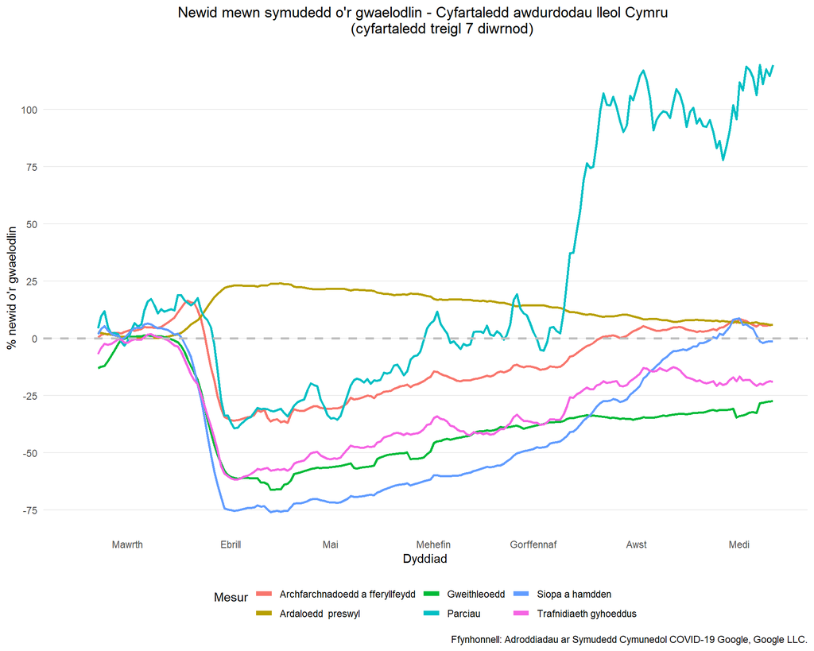

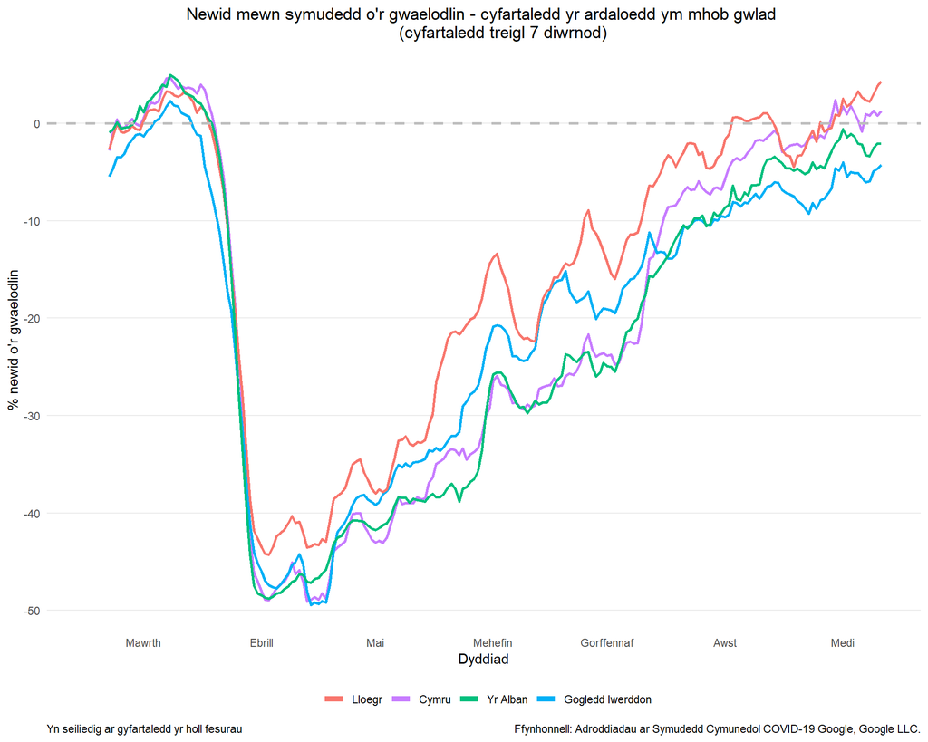

### **Data symudedd Apple**

Mae’r siartiau hyn yn dangos ceisiadau i gynllunio teithiau gan ddefnyddio gwahanol ddulliau teithio ar gyfer y rheini sy’n defnyddio mapiau Apple. Mae’n cynnwys cerdded, gyrru a thrafnidiaeth cyhoeddus (cludiant). 13 Ionawr yw’r gwaelodlin. Cynhyrchir y data drwy gyfrif nifer y ceisiadau i mapiau Apple am gyfarwyddiadau mewn siroedd / rhanbarthau, is-ranbarthau a dinasoedd dethol. Maent i’w cael ar gyfer pob un o’r pedair gwlad a rhai dinasoedd yn y DU, gan gynnwys Caerdydd.

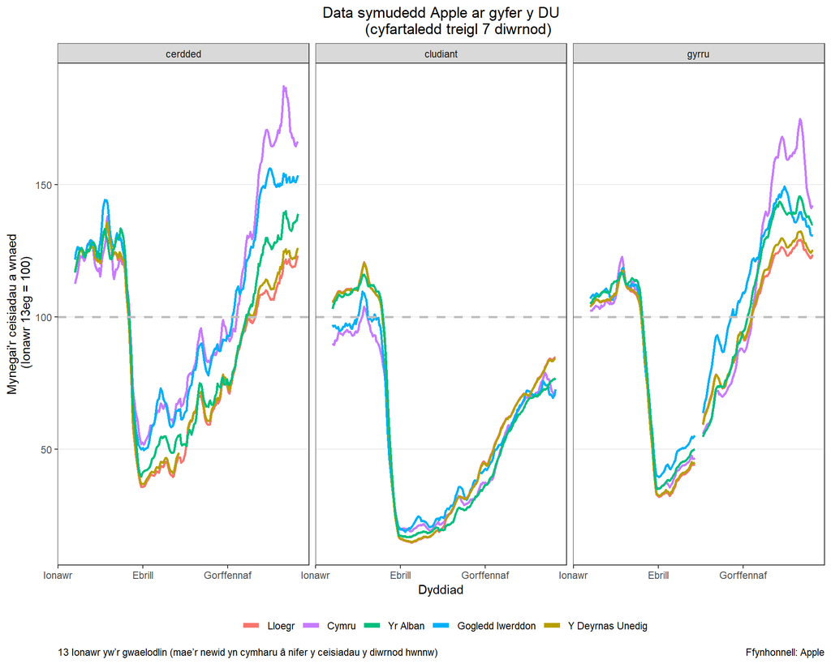

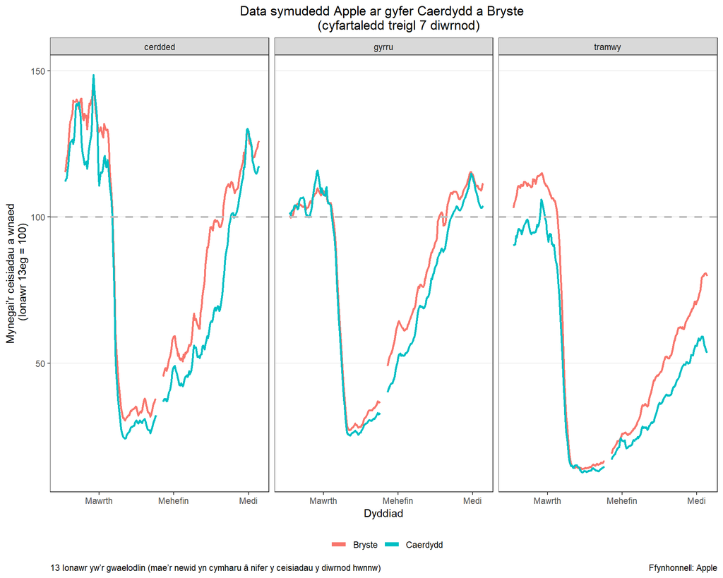

### **Data symudedd Facebook**

Mae’r siartiau hyn yn dangos newidiadau mewn symudedd defnyddwyr Facebook. Dim ond y bobl hynny a fydd wedi dewis galluogi’r gosodiad ar eu dyfeisiau symudol sy’n dangos eu lleoliad ac sy’n caniatáu i ddata am eu lleoliad gael eu defnyddio yn y cefndir sydd wedi cael eu cynnwys. Y cyfnod o 22 - 29 Chwefror yw’r gwaelodlin ac mae’r newidiadau yn cymharu â’r un diwrnod o’r wythnos yn ystod y cyfnod hwnnw. Defnyddir dau fetrig, Newid mewn Symudedd ac Aros yn yr Unfan, sy’n darparu persbectif sydd ychydig yn wahanol ar dueddiadau mewn symudedd. Mae Newid mewn Symudedd yn edrych ar faint y mae pobl yn symud o gwmpas ac yn ei gymharu â chyfnod gwaelodlin sy’n syrthio cyn i’r mesurau cadw pellter cymdeithasol gael eu gweithredu. Mae Aros yn yr Unfan yn edrych ar y ffracsiwn o’r boblogaeth yr ymddengys ei fod yn aros o fewn un ardal fach am ddiwrnod cyfan. Mae data i’w cael ar gyfer pob un o’r pedair gwlad.

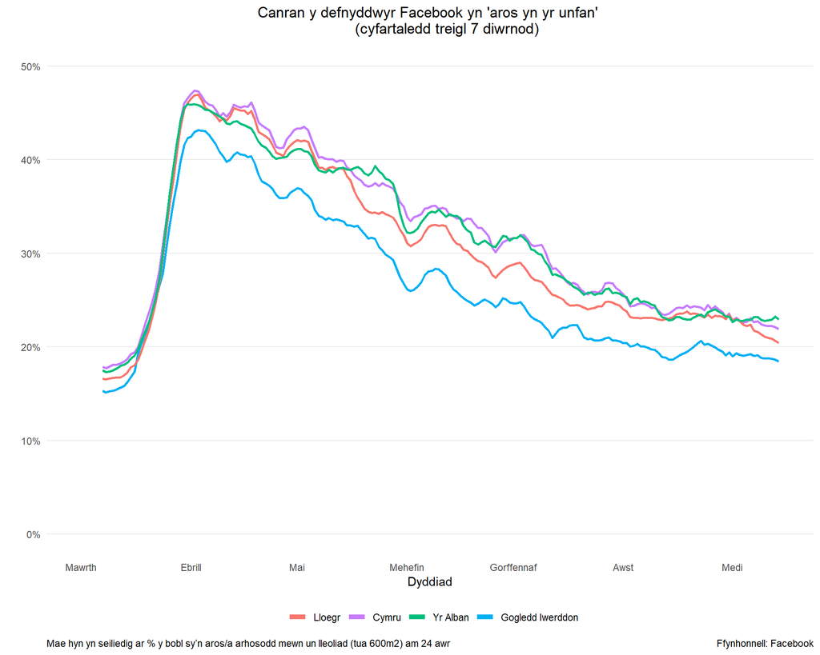

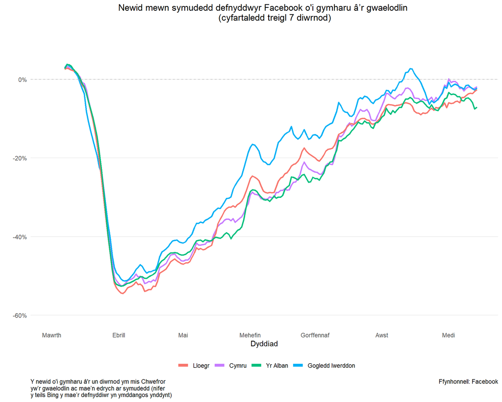